# Ellaine Juvina

Pengantar Tujuan dan Pemandu

Author

Aucloire

Published

October 1, 2025

# Gerbang Aucloire: Peta Komunikasi dan Kompetensi

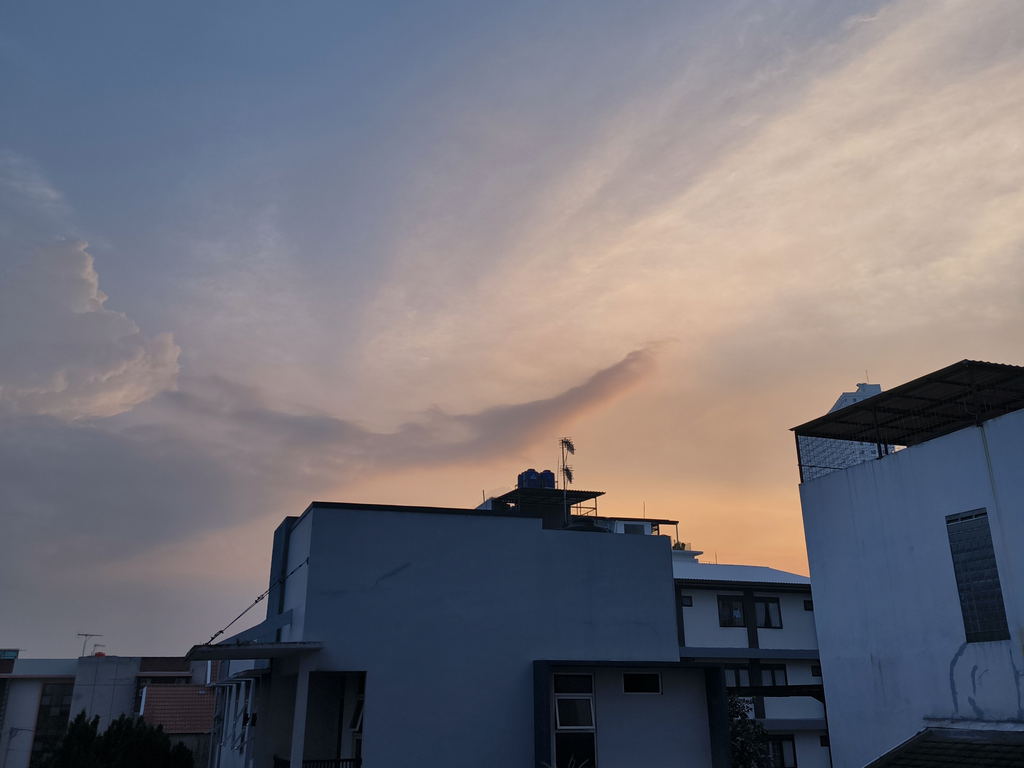

Suatu Senja di Jatinangor, 3 Juni 2025

## Tujuan Situs Ini

Situs ini adalah **Bukti Kompetensi**—dirancang sebagai Asesmen untuk mata kuliah Komunikasi Interpersonal dan Publik (II-2100). Tujuannya adalah mendemonstrasikan kemampuan komunikasi dan menjelaskan konsep diri yang otentik melalui serangkaian proyek terstruktur, yang harus dinilai berdasarkan rubrik *Attractiveness*, *Logic*, dan *Competence*. Seluruh isinya (mulai dari *All About Me* hingga *My Professional Reviews*) berpegang pada prinsip otentisitas, kepercayaan, dan logika gagasan.

## Mengenal Aucloire: Pemandu Kontras Karakter

Saya adalah **Aucloire**. Saya hadir sebagai **Pemandu Narasi** yang bertugas menyajikan sosok Ellaine Juvina—mahasiswi Sistem dan Teknologi Informasi—dengan cara yang menarik namun tetap jujur pada struktur akademik. Saya akan membantu Anda menelusuri kontras yang ada: bagaimana seorang yang sangat **Pragmatis dan Logis** (yang harus menghasilkan *My Concepts* dan *My Knowledge*) ternyata memiliki sisi **artistik dan penggemar Manhwa/K-Pop**; bagaimana Ambisi Kebebasan Finansialnya menjadi fondasi yang menggerakkan setiap Proyek dan *Review* profesional. Setiap narasi yang Anda temukan adalah upaya untuk memenuhi syarat **Daya Tarik** dengan tetap menghormati **Struktur Pembuktian Kompetensi** yang diminta oleh mata kuliah ini.

Silakan jelajahi navigasi di atas (My Songs for You, My Stories for You, hingga My Professional Reviews) untuk memulai penjelajahan kompetensi.